# Star Ratings: The Student Sample (Pod 1 × Pod 3) Compared With the Online Mixed Design Study

Author

Jamie C. Lee

Published

November 12, 2026

**NoteReminder: the Pod 3 design**

**Pod 3 = MKT F26 Exp 3, “Digital vs. Physical Goods”** (student pool, collected Oct 26–Nov 6, 2026). The same people did Pod 1 (the 0.4-step pairs) in September.

**The star-rating block:**

- An intro screen: *“In this next section, you will see 4 pairs of ratings, presented one pair at a time. Each rating will fall on a **5-point rating scale**…”*
- **4 whole-number pairs:** 1.0 vs 2.0, 2.0 vs 3.0, 3.0 vs 4.0, 4.0 vs 5.0, **always shown with “out of 5”** (e.g., “Rating A: **3.0** out of 5”). There is no plain-number condition.
- One pair per page, **in random order** (each person’s order is saved in `pair_order` from Oct 28 on).
- Same question and slider as Pod 1 and the Mixed Design: *“On a 1-to-5 rating scale, how large does the difference between these two ratings feel to you?”* (0–100, “No difference at all” to “Extremely different”; the handle appears on click).
- A page timer on each pair (recorded from Oct 28 on).
- **No zero check or probe** in this block, so Pod 3 has no attention exclusion.

**What Pod 3 does not have, compared with the Mixed Design:** 0.4-step pairs (those come from Pod 1, weeks earlier), a plain-number condition, and block-order counterbalancing.

**ImportantWhere this report sits in the pre-registration**

The AsPredicted pre-registration “Rating Perceptions Mixed Design” covers **two samples**:

- **Online sample (Prolific): confirmatory.** H1 and H2 are tested only here. This is the Mixed Design study in `mixed_design_analysis.html`.
- **Student sample: exploratory.** It is exactly the data in this report: undergraduates who did the 0.4-step block, with “out of 5”, in an earlier study (**Pod 1**), linked by participant ID to the whole-number block from a second session (**Pod 3**).

**H1 and H2 were developed from the Pod 1 data.** That is why the student sample can’t confirm them: Pod 1 agreeing with H1 and H2 is expected, not independent evidence. So when this report says a finding “replicated” in the students, it means the same test came out significant in both samples, not that the students independently confirm it. The report carries out two comparisons the pre-registration lists as exploratory:

> *“the H1 and H2 measures compared between samples, and checked for effects of block order”*

> *“whether H1 holds or differs in the round numbers condition”* (the whole-number block)

The **whole-number data (Pod 3) are new**: they played no part in forming the hypotheses. Even so, they remain exploratory.

The pre-registration also notes that the samples differ in more than population: students did the blocks in a fixed order, weeks apart, with the 0.4 block always “out of 5”. So differences between the samples can’t be put down to the sample alone.

**TipThe two pre-registered hypotheses**

Both use only the **0.4-step pairs** (for students, these come from Pod 1). Every pair is exactly 0.4 stars apart, so if people read the scale literally, every pair would feel equally different.

- **H1: A 0.4-star gap feels bigger near the top of the scale than near the bottom.** For example, 4.0 vs 4.4 should feel more different than 1.0 vs 1.4.

  > Pre-registered test: *“For each participant, the mean response to the six within-star pairs in the 4s (4.0 vs 4.4 through 4.5 vs 4.9) is compared with the mean response to the six in the 1s (1.0 vs 1.4 through 1.5 vs 1.9), using a paired t-test (one-sided, 4s larger, α = .05).”*
- **H2: Reaching a whole number feels bigger than leaving it.** For example, 2.6 vs **3.0** (ending on 3) should feel more different than **3.0** vs 3.4 (starting from 3), even though both gaps are 0.4.

  > Pre-registered test: *“At each whole star k = 2, 3 and 4, we compare each participant’s response to the pair ending at k (k − 0.4 vs k, e.g., 2.6 vs 3.0) with their response to the pair starting at k (k vs k + 0.4, e.g., 3.0 vs 3.4). We code 1 if the ending pair received the larger response and 0 if the smaller; ties are left out. At each whole star, we test whether the proportion coded 1 exceeds 50% using an exact binomial test (one-sided, α = .05), with a Holm correction across the three tests.”*

**One deviation, shared with the Mixed Design report:** H1 is tested **two-sided** here, not one-sided as pre-registered. Two-sided is stricter, so it can only make H1 harder to find; every H1 result is p < .001 either way. H2 follows the pre-registration exactly.

The **whole-number findings** (4 vs 5, 3 vs 4, …) were exploratory in the Mixed Design. For students they come from Pod 3.

# Bottom line

**Benchmark: the online sample’s “out of 5” group** (the confirmatory Mixed Design study, n = 236), because the student sample saw “out of 5” throughout. “Pod” below means the student sample (Pod 1 × Pod 3). The pooled Mixed Design sample appears only in the check that this report reproduces `mixed_design_analysis.html` (18 of 18 numbers match).

- **H1 (0.4 gaps feel bigger near the top): replicated, and about twice as large in students.** 0.4 gaps feel bigger in the 4s than in the 1s by 15.0 points in the Mixed Design (p < .001) and by 28.6 points in the students (p < .001). Expected, since H1 came from Pod 1.
- **H2 (reaching a whole number feels bigger than leaving it): replicated only at 4, and only with the exclusions.** In the online “out of 5” group, H2 holds at 3 and 4 (Holm p = .060 / .002 / .001 at 2 / 3 / 4). Pod shows it at 4 (Holm p = .238 / .238 / .021), and at 4 only with the zero-check exclusions (.055 without). The share of people showing it is about the same in both (55% / 54% / 61% in Pod vs 56% / 61% / 62% online), so the misses most likely reflect too few people (149 and 236) to detect a ~55–60% effect rather than a different effect. For reference, the pre-registered test on the whole online sample (both formats, n = 504) finds H2 at 2, 3 and 4.
- **Whole steps (new data from Pod 3): replicated.** Every whole-step comparison is significant in both studies. In particular, **4 vs 5 feels bigger than 3 vs 4** by 4.1 points in the Mixed Design (p < .001) and by 4.1 points in the students (p = .013). 4 vs 5 beats 1 vs 2 by 16.8 and 26.6 points (both p < .001).
- **Order-matched (0.4 pairs first, whole numbers second):** against the Mixed Design’s “out of 5”, 0.4-first group (n = 116), **4 vs 5 is the biggest whole step in both**: most often rated largest (52% vs 50% in Pod), and above 3 vs 4 by 6.4 vs 4.1 points. Pod shows the 0.4-first pattern even with weeks between the blocks (details).
- **Not testable here:** the “out of 5” effect itself and review frequency (Pod has no plain-number condition and no review-frequency question).

# How the studies differ

|  | Mixed Design | Pod 1 × Pod 3 |
| --- | --- | --- |
| Sample | Online panel, “out of 5” group: n = 236 after exclusions (of 504 in the whole study) | Student pool, n = 149 after exclusions |
| Sessions | One session, both blocks | Two sessions weeks apart: 0.4 block (Pod 1, September), whole block (Pod 3, late Oct–Nov) |
| Block order | Counterbalanced | 0.4 block always first, weeks earlier |
| Format | Plain number vs. “out of 5” (between subjects) | “Out of 5” only |
| Exclusions | Bot flags + both zero checks | Both Pod 1 zero checks (no bot flags; no zero check in Pod 3) |
| Context | Stand-alone study | Pod 1 inside a multi-study session; Pod 3 after a willingness-to-pay study |

Because Pod is “out of 5” only, every comparison uses the Mixed Design’s **“out of 5” group**, not its pooled sample. The Mixed Design showed that format matters (H1: 15.0 with “out of 5” vs 10.6 with plain numbers), so the pooled numbers would mix in a condition Pod never had. The benchmark’s tests are rerun within that group (H2 is Holm-corrected within it), so a few of them differ from the pooled results in the Mixed Design report.

**How to read the tables.** Each row runs the same test separately in each study and shows that study’s estimate and p-value. The verdict asks one question: is the effect significant (p < .05) in both?

- *Replicated:* significant in the Mixed Design, and in the student sample with and without its zero-check exclusions.
- *Partly replicated:* significant in the Mixed Design, and in the student sample only with the exclusions.
- *Not replicated:* significant in the Mixed Design, not in the student sample.
- *Not significant in Mixed Design:* there was no Mixed Design effect to replicate.

Tests: H1 and the whole-step rows are two-sided paired t-tests (the whole-step rows test whether the difference between two steps is above 0). H2 is the pre-registered one-sided exact binomial test, Holm-corrected across 2, 3 and 4. For H1 and H2, “replicated” means the students agree with the online sample; it is not independent confirmation, because H1 and H2 were developed from Pod 1.

# Comparison scorecard

```r
welch_vs <- function(x, y) { tt <- t.test(x, y); sprintf("%+.1f, %s", diff(rev(tt$estimate)), p_txt(tt$p.value)) }
cell <- function(tt) sprintf("%.1f [%.1f, %.1f], %s", tt$estimate[1], tt$conf.int[1], tt$conf.int[2], p_txt(tt$p.value))

# compare is accepted but not shown: the tables report each study's own p-value only
row <- function(finding, bench, pod, verdict, compare = "") {
  tibble(Finding = finding, `Mixed Design, out of 5` = bench, `Students (Pod 1 × Pod 3)` = pod,
         Verdict = verdict)
}
h1_ci <- function(h) sprintf("%.1f [%.1f, %.1f], %s", h$diff, h$lo, h$hi, p_txt(h$p))
h2_cell <- function(g, k) sprintf("%s, Holm %s", pct(H2[[g]]$prop[k - 1], 1), p_txt(H2[[g]]$p_holm[k - 1]))
whole_lab_s <- c(top_bottom = "4 vs 5 bigger than 1 vs 2",
                 step2 = "2 vs 3 bigger than 1 vs 2", step3 = "3 vs 4 bigger than 2 vs 3",
                 step4 = "4 vs 5 bigger than 3 vs 4")
modal_top <- function(g) names(which.max(table(TOP[[g]]))) == "4 vs 5"
top_tab   <- function(g) table(factor(TOP[[g]] == "4 vs 5", c(TRUE, FALSE)))
ratio_ok  <- function(r) { tt <- t.test(r, mu = 2.5); tt$p.value < .05 && mean(r) < 2.5 }

# Every verdict uses the Mixed Design "out of 5" group only (Jamie's choice, 2026-11-12)
h1_ok_online <- H1[[B]]$p < .05 && H1[[B]]$diff > 0
h2_ok_online <- H2[[B]]$p_holm < .05
rows <- list(
  row("H1: 0.4 gaps bigger in the 4s than the 1s (pre-registered)",
      h1_ci(H1[[B]]), h1_ci(H1[[P]]),
      verdict(h1_ok_online, H1[[P]]$p < .05 && H1[[P]]$diff > 0,
              run_h1(pod_all)$p < .05 && run_h1(pod_all)$diff > 0),
      welch_vs(h1_scores(pod)$diff, h1_scores(md5)$diff))
)
for (k in 2:4) rows[[length(rows) + 1]] <- row(
  sprintf("H2 at %d: reaching %d.0 feels bigger than leaving it (pre-registered)", k, k),
  h2_cell(B, k), h2_cell(P, k),
  verdict(h2_ok_online[k - 1], H2[[P]]$p_holm[k - 1] < .05, pod_h2_all$p_holm[k - 1] < .05),
  sprintf("Fisher %s", p_txt(fisher_vs(k))))
for (s in names(whole_lab_s)) rows[[length(rows) + 1]] <- row(
  paste("Whole steps:", whole_lab_s[[s]]),
  cell(ws(B, s)), cell(ws(P, s)),
  verdict(sig_pos(ws(B, s)), sig_pos(ws(P, s)), sig_pos(t.test(W_all[[s]]))),
  welch_vs(W[[P]][[s]], W[[B]][[s]]))

scorecard <- bind_rows(rows)
scorecard |>
  kable(caption = "Each finding, tested separately in the Mixed Design's 'out of 5' group and in the students. Cells: estimate [95% CI] in slider points (0–100) and p-value; for H2, % of people showing it and Holm p.") |>
  kable_styling(bootstrap_options = c("striped", "condensed"), font_size = 12) |>
  column_spec(4, bold = TRUE, color = verdict_cols[scorecard$Verdict])
```

Each finding, tested separately in the Mixed Design's 'out of 5' group and in the students. Cells: estimate [95% CI] in slider points (0–100) and p-value; for H2, % of people showing it and Holm p.

| Finding | Mixed Design, out of 5 | Students (Pod 1 × Pod 3) | Verdict |
| --- | --- | --- | --- |
| H1: 0.4 gaps bigger in the 4s than the 1s (pre-registered) | 15.0 [12.4, 17.6], p < .001 | 28.6 [24.8, 32.3], p < .001 | Replicated |
| H2 at 2: reaching 2.0 feels bigger than leaving it (pre-registered) | 55.5%, Holm p = .060 | 55.3%, Holm p = .238 | Not significant in Mixed Design |
| H2 at 3: reaching 3.0 feels bigger than leaving it (pre-registered) | 60.6%, Holm p = .002 | 54.5%, Holm p = .238 | Not replicated |
| H2 at 4: reaching 4.0 feels bigger than leaving it (pre-registered) | 61.8%, Holm p = .001 | 60.7%, Holm p = .021 | Partly replicated |
| Whole steps: 4 vs 5 bigger than 1 vs 2 | 16.8 [13.5, 20.1], p < .001 | 26.6 [21.7, 31.5], p < .001 | Replicated |
| Whole steps: 2 vs 3 bigger than 1 vs 2 | 6.8 [4.8, 8.7], p < .001 | 10.3 [7.2, 13.5], p < .001 | Replicated |
| Whole steps: 3 vs 4 bigger than 2 vs 3 | 5.9 [4.0, 7.8], p < .001 | 12.2 [9.4, 15.1], p < .001 | Replicated |
| Whole steps: 4 vs 5 bigger than 3 vs 4 | 4.1 [2.2, 6.0], p < .001 | 4.1 [0.9, 7.2], p = .013 | Replicated |

**Tally:** 5 replicated, 1 partly replicated, 1 not replicated, 1 not significant in Mixed Design.

# The curves side by side

Same task and slider in both studies, so the means are on the same 0–100 scale. Each point is one pair’s mean, placed at the pair’s higher rating; bars are 95% CIs.

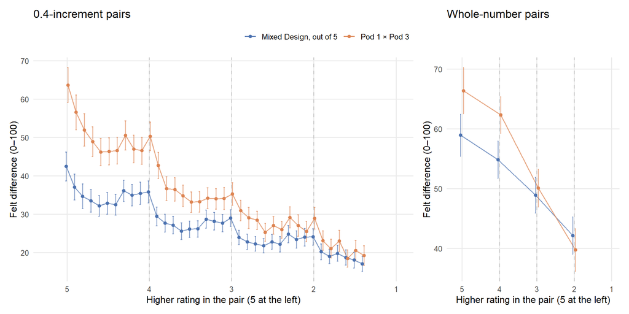

Figure 1: 0.4-increment pairs (left) and whole-number pairs (right) in the Mixed Design’s ‘out of 5’ group and Pod 1 × Pod 3. The x-axis runs from 5 (left) down to 1. The y-axes differ.

```r
long <- function(df, items, lab) {
  df |> select(all_of(items)) |>
    pivot_longer(everything(), names_to = "item", values_to = "resp") |>
    mutate(b = as.numeric(sub("^[dw]", "", item)) + if (grepl("^d", items[1])) 0.4 else 1,
           Sample = lab)
}
sumc <- function(x) x |> group_by(Sample, item, b) |>
  summarise(m = mean(resp), se = sd(resp) / sqrt(n()), .groups = "drop") |>
  mutate(lo = m - 1.96 * se, hi = m + 1.96 * se, Sample = factor(Sample, unique(x$Sample)))
bench_groups <- groups[c(B, P)]
dec_s   <- sumc(bind_rows(mapply(long, bench_groups, list(dec_items), names(bench_groups), SIMPLIFY = FALSE)))
whole_s <- sumc(bind_rows(mapply(long, bench_groups, list(whole_items), names(bench_groups), SIMPLIFY = FALSE)))
cplot <- function(s, title, dodge) {
  ggplot(s, aes(b, m, colour = Sample, group = Sample)) +
    geom_vline(xintercept = 2:4, linetype = "dashed", colour = "grey80") +
    geom_line(alpha = 0.7, position = position_dodge(width = dodge)) +
    geom_errorbar(aes(ymin = lo, ymax = hi), width = 0.04, alpha = 0.6, position = position_dodge(width = dodge)) +
    geom_point(size = 1.6, position = position_dodge(width = dodge)) +
    scale_colour_manual(values = samp_cols, name = NULL) +
    scale_x_reverse(breaks = 5:1, limits = c(5.2, 1)) +          # 5 at the origin
    labs(x = "Higher rating in the pair (5 at the left)", y = "Felt difference (0–100)", title = title)
}
cplot(dec_s, "0.4-increment pairs", 0.04) + cplot(whole_s, "Whole-number pairs", 0.15) +
  plot_layout(widths = c(2.2, 1), guides = "collect") & theme(legend.position = "top")
```

The two studies agree at the bottom of the scale: 1s pairs average 20.9 in Pod and 18.8 in the benchmark. They pull apart higher up (4s pairs: 49.4 vs 33.8), so Pod’s larger H1 gap comes from the top of the scale, not from a general shift in how the slider was used.

# Matched on order: 0.4 pairs first, whole numbers second

Pod participants always rated the 0.4 pairs (Pod 1) before the whole numbers (Pod 3). The closest Mixed Design group is therefore people in the **“out of 5” condition who did the 0.4 block first** (n = 116). In the Mixed Design, block order mattered for the whole numbers: after the 0.4 pairs, 4 vs 5 stood out as the biggest step; with whole numbers first, it didn’t. The “whole first” group (n = 120) is shown as a reference only.

The difference that remains: in the Mixed Design the whole numbers came minutes after the 0.4 pairs; in Pod, weeks later.

## Pre-registered tests

```r
om_row <- function(finding, bench, pod, verdict, compare = "") {
  tibble(Finding = finding, `Mixed Design, out of 5, 0.4 first` = bench, `Students (Pod 1 × Pod 3)` = pod,
         Verdict = verdict)
}
fisher_d <- function(k) {
  a <- H2[[P]][H2[[P]]$k == k, ]; b <- H2[[D]][H2[[D]]$k == k, ]
  fisher.test(matrix(c(a$n_end, a$n_start, b$n_end, b$n_start), 2))$p.value
}
md_d <- groups[[D]]
# Verdicts use the order-matched group's own tests
om_pre <- bind_rows(
  om_row("H1: 0.4 gaps bigger in the 4s than the 1s", h1_ci(H1[[D]]), h1_ci(H1[[P]]),
         verdict(H1[[D]]$p < .05 && H1[[D]]$diff > 0, H1[[P]]$p < .05 && H1[[P]]$diff > 0,
                 run_h1(pod_all)$p < .05 && run_h1(pod_all)$diff > 0),
         welch_vs(h1_scores(pod)$diff, h1_scores(md_d)$diff)),
  bind_rows(lapply(2:4, function(k) om_row(
    sprintf("H2 at %d: reaching %d.0 feels bigger than leaving it", k, k),
    h2_cell(D, k), h2_cell(P, k),
    verdict(H2[[D]]$p_holm[k - 1] < .05, H2[[P]]$p_holm[k - 1] < .05, pod_h2_all$p_holm[k - 1] < .05),
    sprintf("Fisher %s", p_txt(fisher_d(k))))))
)
om_pre |>
  kable(caption = "Pre-registered tests, order-matched, tested separately in each study. Cells: estimate [95% CI] and p-value; for H2, % of people showing it and Holm p.") |>
  kable_styling(bootstrap_options = c("striped", "condensed"), font_size = 12) |>
  column_spec(4, bold = TRUE, color = verdict_cols[om_pre$Verdict])
```

Pre-registered tests, order-matched, tested separately in each study. Cells: estimate [95% CI] and p-value; for H2, % of people showing it and Holm p.

| Finding | Mixed Design, out of 5, 0.4 first | Students (Pod 1 × Pod 3) | Verdict |
| --- | --- | --- | --- |
| H1: 0.4 gaps bigger in the 4s than the 1s | 14.8 [11.0, 18.7], p < .001 | 28.6 [24.8, 32.3], p < .001 | Replicated |
| H2 at 2: reaching 2.0 feels bigger than leaving it | 52.9%, Holm p = .312 | 55.3%, Holm p = .238 | Not significant in Mixed Design |
| H2 at 3: reaching 3.0 feels bigger than leaving it | 59.4%, Holm p = .064 | 54.5%, Holm p = .238 | Not significant in Mixed Design |
| H2 at 4: reaching 4.0 feels bigger than leaving it | 61.8%, Holm p = .033 | 60.7%, Holm p = .021 | Partly replicated |

**H1** is 14.8 in the order-matched Mixed Design group and 28.6 in Pod. **H2** holds at 4 in the order-matched group (53% / 59% / 62% at 2 / 3 / 4) and at 4 in Pod (55% / 54% / 61%). With only 116 people, the order-matched group’s H2 tests at 2 and 3 have little power; in both samples the share of people showing H2 is about the same (Fisher p = .795 / .443 / .894).

## Exploratory: the whole-number block

The same analyses as the Mixed Design report’s whole-number section, for the order-matched group and Pod.

```r
om_whole <- bind_rows(
  lapply(names(whole_lab_s), function(s) om_row(
    paste("Whole steps:", whole_lab_s[[s]]), cell(ws(D, s)), cell(ws(P, s)),
    verdict(sig_pos(ws(D, s)), sig_pos(ws(P, s)), sig_pos(t.test(W_all[[s]]))),
    welch_vs(W[[P]][[s]], W[[D]][[s]]))),
  om_row("Whole steps: 4 vs 5 is the step most often rated largest",
         pct(mean(TOP[[D]] == "4 vs 5")), pct(mean(TOP[[P]] == "4 vs 5")),
         verdict(modal_top(D), modal_top(P), names(which.max(table(largest_step(pod_all)))) == "4 vs 5"),
         sprintf("Fisher %s", p_txt(fisher.test(cbind(top_tab(P), top_tab(D)))$p.value)))
)
om_whole |>
  kable(caption = "Whole-number block, order-matched, tested separately in each study. Cells: difference between steps [95% CI] in slider points and p-value, or % of people.") |>
  kable_styling(bootstrap_options = c("striped", "condensed"), font_size = 12) |>
  column_spec(4, bold = TRUE, color = verdict_cols[om_whole$Verdict])
```

Whole-number block, order-matched, tested separately in each study. Cells: difference between steps [95% CI] in slider points and p-value, or % of people.

| Finding | Mixed Design, out of 5, 0.4 first | Students (Pod 1 × Pod 3) | Verdict |
| --- | --- | --- | --- |
| Whole steps: 4 vs 5 bigger than 1 vs 2 | 20.4 [15.1, 25.6], p < .001 | 26.6 [21.7, 31.5], p < .001 | Replicated |
| Whole steps: 2 vs 3 bigger than 1 vs 2 | 6.9 [4.1, 9.7], p < .001 | 10.3 [7.2, 13.5], p < .001 | Replicated |
| Whole steps: 3 vs 4 bigger than 2 vs 3 | 7.1 [4.4, 9.8], p < .001 | 12.2 [9.4, 15.1], p < .001 | Replicated |
| Whole steps: 4 vs 5 bigger than 3 vs 4 | 6.4 [4.0, 8.7], p < .001 | 4.1 [0.9, 7.2], p = .013 | Replicated |
| Whole steps: 4 vs 5 is the step most often rated largest | 52% | 50% | Replicated |

```r
top_levels <- c(whole_lab, "Tie")
top_share  <- function(g) sprintf("%.0f%%", 100 * as.numeric(table(factor(TOP[[g]], top_levels))) / length(TOP[[g]]))
tibble(`Largest step` = top_levels,
       `Mixed Design, whole first (reference)` = top_share(Wf),
       `Mixed Design, 0.4 first` = top_share(D),
       `Pod 1 × Pod 3` = top_share(P)) |>
  kable(caption = "Which whole-number step each person rated largest (\"out of 5\" only)") |>
  kable_styling(full_width = FALSE)
```

Which whole-number step each person rated largest ("out of 5" only)

| Largest step | Mixed Design, whole first (reference) | Mixed Design, 0.4 first | Pod 1 × Pod 3 |
| --- | --- | --- | --- |
| 1 vs 2 | 14% | 9% | 8% |
| 2 vs 3 | 16% | 8% | 8% |
| 3 vs 4 | 19% | 13% | 28% |
| 4 vs 5 | 40% | 52% | 50% |
| Tie | 11% | 19% | 6% |

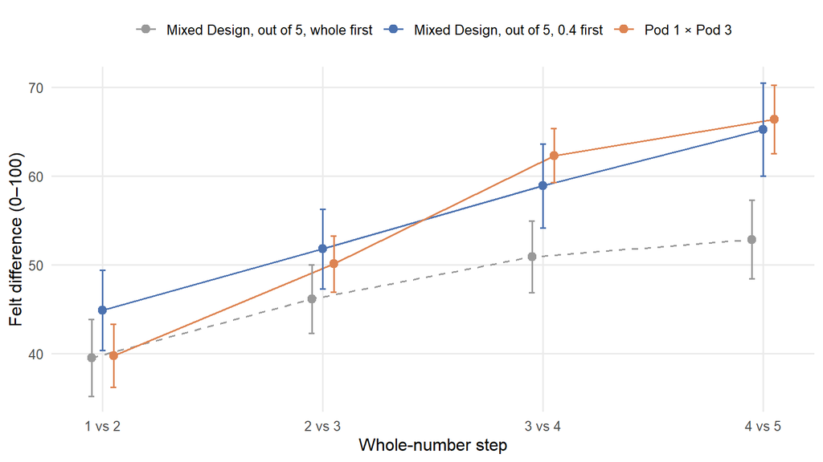

Figure 2: Mean felt difference for each whole-number step, with 95% CIs. Dashed line: the Mixed Design’s whole-first group, for reference.

```r
om_cols <- c("Mixed Design, out of 5, whole first" = "grey60", "Mixed Design, out of 5, 0.4 first" = "#4C72B0",
             "Pod 1 × Pod 3" = "#DD8452")
om_groups <- groups[names(om_cols)]
om_s <- sumc(bind_rows(mapply(long, om_groups, list(whole_items), names(om_groups), SIMPLIFY = FALSE))) |>
  mutate(Sample = factor(as.character(Sample), names(om_cols)))
ggplot(om_s, aes(b, m, colour = Sample, group = Sample, linetype = Sample)) +
  geom_line(position = position_dodge(width = 0.15)) +
  geom_errorbar(aes(ymin = lo, ymax = hi), width = 0.08, linetype = "solid", position = position_dodge(width = 0.15)) +
  geom_point(size = 2.5, position = position_dodge(width = 0.15)) +
  scale_colour_manual(values = om_cols, name = NULL) +
  scale_linetype_manual(values = c("dashed", "solid", "solid"), name = NULL) +
  scale_x_continuous(breaks = 2:5, labels = whole_lab) +
  labs(x = "Whole-number step", y = "Felt difference (0–100)")
```

**Is 4 vs 5 the biggest step? Yes, in both.** It is the step people most often rate largest (52% in the order-matched Mixed Design group, 50% in Pod), and it is bigger than 3 vs 4 by 6.4 points [4.0, 8.7] and 4.1 points [0.9, 7.2] (difference between samples p = .255). In the whole-first group it is only 1.9 points, p = .180.

**The height of the top steps tells the order story more clearly than the increments.** Pod and the whole-first group start at the same level (1 vs 2: 39.8 vs 39.5, p = .937). At the top, Pod sits with the 0.4-first group, not the whole-first group: 4 vs 5 is 66.4 in Pod, 65.2 after the 0.4 pairs (p = .732) and 52.9 with whole numbers first (p < .001). The Mixed Design report noted that doing the 0.4 block first raised the whole-number steps; in Pod, the upper steps are raised to the same height even with weeks in between.

**What this does and doesn’t show.** Pod matches the 0.4-first pattern: 4 vs 5 is the biggest step, and the upper steps are as high as after the 0.4 pairs. But the *increment* from 3 vs 4 to 4 vs 5 doesn’t separate the groups (Pod vs whole first: p = .326), and Pod differs from the Mixed Design in sample and setting, not only in order. Without a whole-first group in Pod, these data can’t show that the earlier 0.4 pairs *caused* the high top steps.

# Possible reasons for the differences

These are not tested here; each is a difference between the studies that could produce the pattern.

- **H1 is about twice as large in Pod.** First, selection: H1 was written after seeing the Pod 1 data, and a pattern chosen because it looked strong in one dataset usually comes out smaller in fresh data, so part of the gap may be this. Second, the samples differ: students vs. an online panel (who reads reviews, and how often); Pod 1’s 0.4 block came without a whole-number block in the same session; and Pod 1 sat inside a longer multi-study session. The Mixed Design’s own block-order split did not change H1, which argues against the missing whole-number block as the main reason.
- **H2 is weaker in Pod.** The percentages match the benchmark’s, but an exact binomial test on ~140–150 non-tied people (Pod) or ~220 (benchmark) has limited power for a 55–60% share. The benchmark itself misses at 2, and Pod at 4 depends on the exclusions.
- **Whole steps are steeper in Pod and feel smaller relative to 0.4 gaps** (ratio 1.54 vs 1.88). The ratio mixes two sessions in Pod, so it is the least comparable number here.

# Check: the recomputation reproduces the Mixed Design report

Numbers typed in from `mixed_design_analysis.html` (Main results and the tables they come from), next to the same quantities recomputed here with that report’s code and exclusions, rounded to the report’s precision.

```r
reported |>
  transmute(Quantity, Reported = sprintf(paste0("%.", digits, "f"), Reported),
            Recomputed = sprintf(paste0("%.", digits, "f"), Recomputed),
            Match = if_else(Match, "Yes", "NO")) |>
  kable() |> kable_styling(full_width = FALSE)
```

| Quantity | Reported | Recomputed | Match |
| --- | --- | --- | --- |
| Analysis sample (n) | 504 | 504 | Yes |
| H1 difference, 4s − 1s | 12.7 | 12.7 | Yes |
| H1 95% CI, lower | 10.9 | 10.9 | Yes |
| H1 95% CI, upper | 14.4 | 14.4 | Yes |
| H1 Cohen's dz | 0.63 | 0.63 | Yes |
| H1 % of people showing it | 74 | 74 | Yes |
| H2 % ending larger at 2 | 56.5 | 56.5 | Yes |
| H2 % ending larger at 3 | 58.4 | 58.4 | Yes |
| H2 % ending larger at 4 | 59.7 | 59.7 | Yes |
| H1 gap, out of 5 | 15.0 | 15.0 | Yes |
| Whole: 4 vs 5 minus 1 vs 2 | 13.3 | 13.3 | Yes |
| Whole: 2 vs 3 minus 1 vs 2 | 5.0 | 5.0 | Yes |
| Whole: 3 vs 4 minus 2 vs 3 | 4.8 | 4.8 | Yes |
| Whole: 4 vs 5 minus 3 vs 4 | 3.4 | 3.4 | Yes |
| % rating 4 vs 5 the largest step | 45 | 45 | Yes |
| 4 vs 5 minus 3 vs 4, whole first | 1.4 | 1.4 | Yes |
| 4 vs 5 minus 3 vs 4, decimal first | 5.6 | 5.6 | Yes |
| Whole ÷ 0.4 (ratio of means) | 1.90 | 1.90 | Yes |